# 6 Map projections

In this chapter, we detach the concept of `Point` from its **geospatial coordinates** in a given [coordinate reference system](https://en.wikipedia.org/wiki/Spatial_reference_system) (CRS). We explain how the same point in the physical world can be represented with multiple geospatial coordinates, and illustrate various types of CRS catalogued in the [EPSG Dataset](https://epsg.org/home.html).

The framework classifies the various CRS as `Basic`, `Geographic` or `Projected`, all of which can depend on a **geodetic datum**. The following sections introduce these very important concepts in geospatial data science, as well as the `Proj` transform for CRS conversion.

## 6.1 Basic

In previous chapters, the construction of geometries assumed a `Cartesian` Coordinate Reference System, or CRS for short. In all previous examples, we constructed `Point`s with `Cartesian` coordinates in `m` units:

```julia
point = Point(1, 2)
```

```
Point with Cartesian{NoDatum} coordinates
├─ x: 1.0 m
└─ y: 2.0 m
```

These coordinates can be retrieved with the `coords` function:

```julia
cart = coords(point)
```

```
Cartesian{NoDatum} coordinates
├─ x: 1.0 m
└─ y: 2.0 m
```

**Note**

Other units from Unitful.jl can be specified with the `u"..."` syntax:

```julia
Point(1u"ft", 2u"cm")
```

```
Point with Cartesian{NoDatum} coordinates
├─ x: 0.3048 m
└─ y: 0.02 m
```

**Note**

The syntax

```julia
Point(x, y, ...)
```

is an alias to

```julia
Point(Cartesian(x, y, ...))
```

To represent the same point in a `Polar` CRS, in terms of a radius `ρ` and an angle `ϕ`, we can convert its coordinates and reconstruct the point:

```julia
polar = convert(Polar, cart)
```

```
Polar{NoDatum} coordinates
├─ ρ: 2.23606797749979 m
└─ ϕ: 1.1071487177940904 rad
```

```julia
Point(polar)
```

```
Point with Polar{NoDatum} coordinates
├─ ρ: 2.23606797749979 m
└─ ϕ: 1.1071487177940904 rad
```

Even though this process is transparent, it would be very tedious to perform this conversion for all `Point`s of `Geometry`s in a `domain` of a `GeoTable`, and reconstruct the result efficiently. That is where the `Proj` transform becomes useful:

```julia
Point(1, 2) |> Proj(Polar)
```

```
Point with Polar{NoDatum} coordinates
├─ ρ: 2.23606797749979 m
└─ ϕ: 1.1071487177940904 rad
```

This transform takes vectors of `Geometry`s, `Domain` or `GeoTable` and converts the underlying coordinates to a given target CRS efficiently, exploiting lazy representations of `Grid`s:

```julia
CartesianGrid(100, 100, 100) |> Proj(Cylindrical)
```

```
100×100×100 TransformedGrid
  1030301 vertices
  ├─ Point(ρ: 0.0 m, ϕ: 0.0 rad, z: 0.0 m)
  ├─ Point(ρ: 1.0 m, ϕ: 0.0 rad, z: 0.0 m)
  ├─ Point(ρ: 2.0 m, ϕ: 0.0 rad, z: 0.0 m)
  ├─ Point(ρ: 3.0 m, ϕ: 0.0 rad, z: 0.0 m)
  ├─ Point(ρ: 4.0 m, ϕ: 0.0 rad, z: 0.0 m)
  ⋮
  ├─ Point(ρ: 138.62178760930766 m, ϕ: 0.8058034940839864 rad, z: 100.0 m)
  ├─ Point(ρ: 139.31618714277246 m, ϕ: 0.8006254127745656 rad, z: 100.0 m)
  ├─ Point(ρ: 140.0142849854971 m, ϕ: 0.7954988299827702 rad, z: 100.0 m)
  ├─ Point(ρ: 140.71602609511115 m, ϕ: 0.7904232467282607 rad, z: 100.0 m)
  └─ Point(ρ: 141.4213562373095 m, ϕ: 0.7853981633974483 rad, z: 100.0 m)
  1000000 elements
  ├─ Hexahedron(1, 2, 103, 102, 10202, 10203, 10304, 10303)
  ├─ Hexahedron(2, 3, 104, 103, 10203, 10204, 10305, 10304)
  ├─ Hexahedron(3, 4, 105, 104, 10204, 10205, 10306, 10305)
  ├─ Hexahedron(4, 5, 106, 105, 10205, 10206, 10307, 10306)
  ├─ Hexahedron(5, 6, 107, 106, 10206, 10207, 10308, 10307)
  ⋮
  ├─ Hexahedron(1019994, 1019995, 1020096, 1020095, 1030195, 1030196, 1030297, 1030296)
  ├─ Hexahedron(1019995, 1019996, 1020097, 1020096, 1030196, 1030197, 1030298, 1030297)
  ├─ Hexahedron(1019996, 1019997, 1020098, 1020097, 1030197, 1030198, 1030299, 1030298)
  ├─ Hexahedron(1019997, 1019998, 1020099, 1020098, 1030198, 1030199, 1030300, 1030299)
  └─ Hexahedron(1019998, 1019999, 1020100, 1020099, 1030199, 1030200, 1030301, 1030300)
```

Although the conversion between `Basic` CRS doesn’t affect the position of points:

```julia
Point(cart) ≈ Point(polar)
```

```
true
```

It can be useful to write geospatial algorithms in terms of specific coordinates of interest:

```julia
cart.x
```

```
1.0 m
```

```julia
cart.y
```

```
2.0 m
```

```julia
polar.ρ
```

```
2.23606797749979 m
```

```julia
polar.ϕ
```

```
1.1071487177940904 rad
```

All coordinate values in the framework have well-defined units to facilitate the development of geospatial applications with full support for different unit systems (e.g., English units).

**NoteTip for all users**

Unitful coordinate values address many pitfalls in geospatial applications. A simple comparison of coordinate values without units can lead to major engineering failures such as the [roller coaster derailment](https://web.archive.org/web/20100923105150/http://lamar.colostate.edu/~hillger/unit-mixups.html#spacemountain) at Tokyo Disneyland’s Space Mountain.

Consider writing algorithms with units to avoid trivial issues in critical applications:

```julia
cart.x < 2u"ft"
```

```
false
```

```julia
ustrip(cart.x) < 2
```

```
true
```

**NoteTip for advanced users**

The result of the `coords` function is **not** a vector, and therefore cannot be used in linear algebra. To retrieve the `Vec` from the origin of the CRS to the given `Point`, use the `to` function instead:

```julia
to(point)
```

```
Vec(1.0 m, 2.0 m)
```

This utility function will always convert the CRS of the coordinates of the `Point` to `Cartesian` before returning the static vector:

```julia
p = Point(polar)
```

```
Point with Polar{NoDatum} coordinates
├─ ρ: 2.23606797749979 m
└─ ϕ: 1.1071487177940904 rad
```

```julia
v = to(p)
```

```
Vec(1.0000000000000002 m, 2.0 m)
```

## 6.2 Geographic

Unlike `Basic` CRS, which are commonly employed in engineering applications where the geospatial domain is small compared to the Earth, `Geographic` CRS depend on a [geodetic datum](https://en.wikipedia.org/wiki/Geodetic_datum):

**TipDefinition**

A **geodetic datum** is the combination of a **ellipsoid of revolution** (a.k.a., spheroid) that approximates the surface of the Earth and a **reference physical point** that identifies the origin of the CRS.

To illustrate this concept, we start with the most widely used `Geographic` CRS:

```julia
latlon = LatLon(0, 90)
```

```
GeodeticLatLon{WGS84Latest} coordinates
├─ lat: 0.0°
└─ lon: 90.0°
```

**Note**

`LatLon` is an alias for `GeodeticLatLon`.

In the geodetic `LatLon` CRS, the longitude coordinate is the horizontal angle measured in degrees from the Greenwich (or prime) meridian:

```julia
latlon.lon
```

```
90.0°
```

The latitude coordinate is the vertical angle measured in degrees from the Equator parallel:

```julia
latlon.lat
```

```
0.0°
```

The geodetic datum of this CRS can be retrieved with the `datum` function:

```julia
datum(latlon)
```

```
WGS84Latest (alias for WGS84{2296})
```

It contains the ellipsoid of revolution:

```julia
ellipsoid(datum(latlon))
```

```
CoordRefSystems.WGS84🌎
```

as well as other parameters used to convert from longitude and latitude angles to `Cartesian` coordinates in meters:

```julia
convert(Cartesian, latlon)
```

```
Cartesian{WGS84Latest} coordinates
├─ x: 3.905482530786651e-10 m
├─ y: 6.378137e6 m
└─ z: 0.0 m
```

In this case, the `WGS84Latest` datum is propagated to the `Cartesian` CRS, which is no longer the default `NoDatum` of previous examples. The datum is used to display geometries with their actual shapes and sizes in the physical world:

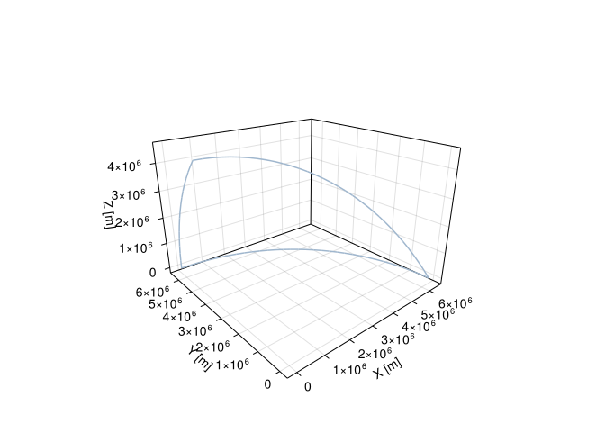

```julia
A = Point(LatLon(0, 0))
B = Point(LatLon(0, 90))
C = Point(LatLon(45, 90))

segments = [Segment(A, B), Segment(B, C), Segment(A, C)]

viz(segments)
```

**Note**

All datum parameters are stored in the CRS type itself at compile time, and are statically retrieved by the Julia compiler during CRS conversion. This leads to extremely efficient code, and consequently extremely efficient `Proj`ections of large geotables.

Below is a more familiar example loaded with the GeoIO.jl module:

```julia
using GeoIO

world = GeoIO.load("data/countries.geojson")
```

167 rows omitted

| 177×3 GeoTable over 177 GeometrySet COUNTRY Categorical [NoUnits] | 177×3 GeoTable over 177 GeometrySet REGION Categorical [NoUnits] | 177×3 GeoTable over 177 GeometrySet geometry MultiPolygon 🖈 GeodeticLatLon{WGS84Latest} |
| --- | --- | --- |
| Fiji | Melanesia | Multi(3×Pgon) |
| Tanzania | Eastern Africa | Multi(1×Pgon) |
| W. Sahara | Northern Africa | Multi(1×Pgon) |
| Canada | Northern America | Multi(30×Pgon) |
| United States of America | Northern America | Multi(10×Pgon) |
| Kazakhstan | Central Asia | Multi(1×Pgon) |
| Uzbekistan | Central Asia | Multi(1×Pgon) |
| Papua New Guinea | Melanesia | Multi(4×Pgon) |
| Indonesia | South-Eastern Asia | Multi(13×Pgon) |
| Argentina | South America | Multi(2×Pgon) |
| ⋮ | ⋮ | ⋮ |

The `GeodeticLatLon` CRS is displayed in the subheader of the `geometry` column. It is used internally by the framework for advanced visualization and geometric processing:

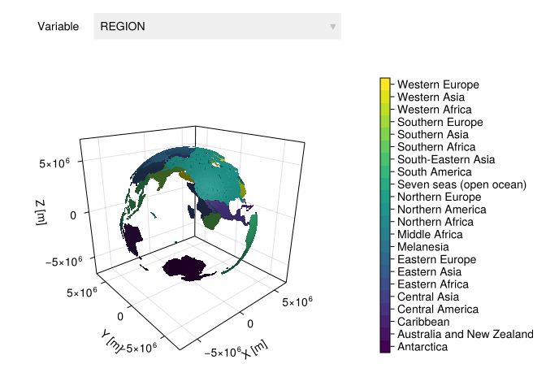

```julia
world |> Select("REGION") |> viewer
```

We can convert the `GeodeticLatLon` CRS to a `GeocentricLatLon` CRS where the latitude coordinate is measured with respect to the center of the ellipsoid:

```julia
world |> Proj(GeocentricLatLon)
```

167 rows omitted

| 177×3 GeoTable over 177 GeometrySet COUNTRY Categorical [NoUnits] | 177×3 GeoTable over 177 GeometrySet REGION Categorical [NoUnits] | 177×3 GeoTable over 177 GeometrySet geometry MultiPolygon 🖈 GeocentricLatLon{WGS84Latest} |
| --- | --- | --- |
| Fiji | Melanesia | Multi(3×Pgon) |
| Tanzania | Eastern Africa | Multi(1×Pgon) |
| W. Sahara | Northern Africa | Multi(1×Pgon) |
| Canada | Northern America | Multi(30×Pgon) |
| United States of America | Northern America | Multi(10×Pgon) |
| Kazakhstan | Central Asia | Multi(1×Pgon) |
| Uzbekistan | Central Asia | Multi(1×Pgon) |
| Papua New Guinea | Melanesia | Multi(4×Pgon) |
| Indonesia | South-Eastern Asia | Multi(13×Pgon) |
| Argentina | South America | Multi(2×Pgon) |
| ⋮ | ⋮ | ⋮ |

or to a geodetic `LatLonAlt`, which also includes the altitude coordinate in meters:

```julia
world |> Proj(LatLonAlt) |> domain |> first
```

```
Multi(3×Pgon)
├─ Pgon((lat: -16.0671°, lon: 180.0°, alt: 0.0 m), ..., (lat: -16.5552°, lon: 180.0°, alt: 0.0 m))
├─ Pgon((lat: -17.5048°, lon: 178.126°, alt: 0.0 m), ..., (lat: -17.3399°, lon: 178.374°, alt: 0.0 m))
└─ Pgon((lat: -16.0209°, lon: -179.793°, alt: 0.0 m), ..., (lat: -16.5018°, lon: -179.917°, alt: 0.0 m))
```

The `crs` function can be used to retrieve the CRS of any given `Geometry`, `Domain`, or `GeoTable` for use in the `Proj` transform:

```julia
crs(world)
```

```
GeodeticLatLon{WGS84Latest, Quantity{Float64, NoDims, Unitful.FreeUnits{(°,), NoDims, nothing}}}
```

As a final example to illustrate the importance of the datum, consider the CRS conversion that preserves the definition of the coordinates, but changes the datum from `WGS84Latest` to `ITRFLatest`:

```julia
Point(LatLon(45, 45)) |> Proj(LatLon{ITRFLatest})
```

```
Point with GeodeticLatLon{ITRFLatest} coordinates
├─ lat: 45.000000000943224°
└─ lon: 45.0°
```

These are still longitude and latitude coordinates, but measured with respect to a different ellipsoid:

```julia
ellipsoid(ITRFLatest)
```

```
CoordRefSystems.GRS80🌎
```

From these examples, we can see that the `Proj` transform accepts a `CRS` or a `CRS{Datum}` type. In the latter case, the new coordinates are expressed in terms of the specified datum:

```julia
Point(LatLon(45, 45)) |> Proj(LatLonAlt{WGS84{2139}})
```

```
Point with GeodeticLatLonAlt{WGS84{2139}} coordinates
├─ lat: 45.000000053516594°
├─ lon: 44.999999990497585°
└─ alt: -0.0037412522360682487 m
```

**Note**

The `WGS84Latest` datum is by far the most widely used datum in the world (e.g., GPS devices). It is often confused with the `WGS84🌎` ellipsoid, which is not exported by the framework:

```julia
ellipsoid(WGS84Latest)
```

```
CoordRefSystems.WGS84🌎
```

## 6.3 Projected

We are finally ready to introduce `Projected` CRS. These are 2D coordinate reference systems obtained from longitude and latitude via specific mathematical formulae. The literature on this subject is quite dense, and it suffices to know that these formulas can be generally written as

$$x = f_x(\lambda, \varphi),\quad y = f_y(\lambda, \varphi)$$

where $x$ and $y$ are the projected coordinates from longitude $\lambda$ and latitude $\varphi$.

Different formulas $f_x$ and $f_y$ were proposed in the literature to preserve properties of geometries such as shape, size and angle. Since it is not possible to preserve all these properties at once, one must choose a `Projected` CRS carefully with the `Proj` transform before sending the geotable to the `viewer`, or before performing geometric calculations (e.g., distances).

Let’s start with the historically famous `Mercator` CRS, designed to preserve angles (or bearings) for navigation. Its formulas are given by

$$x = R(\lambda - \lambda_o), \quad y = R\ln\left(\tan\left(\frac{\pi}{4} + \frac{\varphi}{2}\right)\right)$$

where $R$ is the major semiaxis of the ellipsoid of the datum, and $\lambda_o$ is the longitude of the origin (or central) meridian, not necessarily the Greenwich (i.e., $\lambda_o=0$). We can `viz` the result of the formulas on a `RegularGrid` of `LatLon` coordinates:

```julia
start  = Point(LatLon(-80, -180))
finish = Point(LatLon(84, 180))

grid = RegularGrid(start, finish, dims=(20, 20))
```

```
20×20 RegularGrid
├─ minimum: Point(lat: -80.0°, lon: -180.0°)
├─ maximum: Point(lat: 84.0°, lon: 180.0°)
└─ spacing: (8.2°, 18.0°)
```

**Note**

The `Mercator` CRS is not well-defined at the poles $\varphi = \pm 90^\circ$. It is common to restrict the visualization to the $-80^\circ \le \varphi \le 84^\circ$ latitude range.

```julia
pgrid = grid |> Proj(Mercator)
```

```
20×20 TransformedGrid
  441 vertices
  ├─ Point(x: -2.0037508342789244e7 m, y: -1.5496570739723716e7 m)
  ├─ Point(x: -2.0037508342789244e7 m, y: -1.1640877666645138e7 m)
  ├─ Point(x: -2.0037508342789244e7 m, y: -9.210594404921511e6 m)
  ├─ Point(x: -2.0037508342789244e7 m, y: -7.404688904937668e6 m)
  ├─ Point(x: -2.0037508342789244e7 m, y: -5.943414207077789e6 m)
  ⋮
  ├─ Point(x: 2.0037508342789244e7 m, y: 6.623426821665486e6 m)
  ├─ Point(x: 2.0037508342789244e7 m, y: 8.230536506199419e6 m)
  ├─ Point(x: 2.0037508342789244e7 m, y: 1.0289594640053453e7 m)
  ├─ Point(x: 2.0037508342789244e7 m, y: 1.3244148388311565e7 m)
  └─ Point(x: 2.0037508342789244e7 m, y: 1.8764656231380563e7 m)
  400 elements
  ├─ Quadrangle(1, 2, 23, 22)
  ├─ Quadrangle(2, 3, 24, 23)
  ├─ Quadrangle(3, 4, 25, 24)
  ├─ Quadrangle(4, 5, 26, 25)
  ├─ Quadrangle(5, 6, 27, 26)
  ⋮
  ├─ Quadrangle(415, 416, 437, 436)
  ├─ Quadrangle(416, 417, 438, 437)
  ├─ Quadrangle(417, 418, 439, 438)
  ├─ Quadrangle(418, 419, 440, 439)
  └─ Quadrangle(419, 420, 441, 440)
```

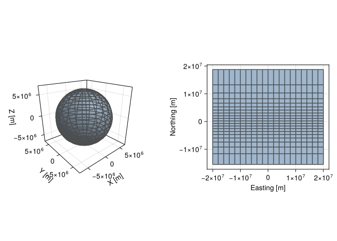

```julia
fig = Mke.Figure()
viz(fig[1,1], grid, showsegments = true)
viz(fig[1,2], pgrid, showsegments = true)
fig
```

It is clear from the visualization that areas are distorted away from the Equator. In other words, the `Mercator` CRS is not adequate for area calculations near the poles:

```julia
extrema(area.(pgrid))
```

```
(1.8196349467139988e12 m^2, 1.1061722196192861e13 m^2)
```

If the domain of interest is located far away from the Equator, and there is a need for area calculations, we can use other `Projected` CRS such as `LambertCylindrical` or `GallPeters`:

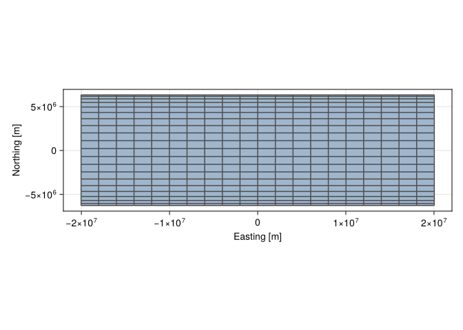

```julia
viz(grid |> Proj(LambertCylindrical), showsegments = true)
```

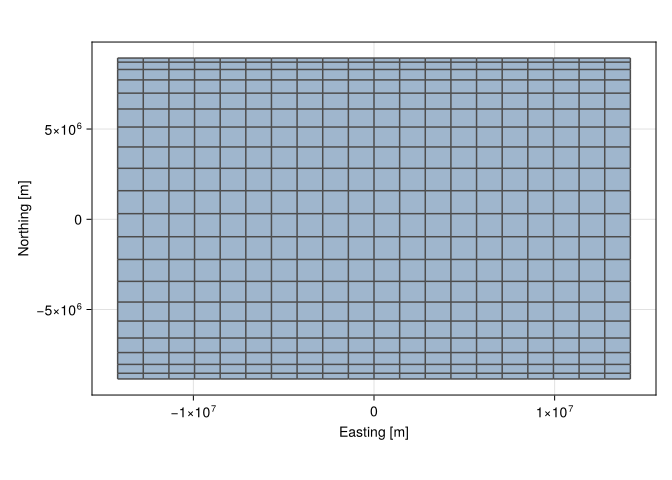

```julia
viz(grid |> Proj(GallPeters), showsegments = true)
```

The formulas of some `Projected` CRS are quite evolved, and sometimes depend on tabulated values. Fortunately, this hard work has already been done in the CoordRefSystems.jl module.

**NoteTip for advanced users**

Custom formulas can be quickly explored with the `Morphological` transform. It takes a function as input that maps one CRS into another. As an example, consider the [sinusoidal projection](https://en.wikipedia.org/wiki/Sinusoidal_projection) defined by

$$x = (\lambda - \lambda_o) \cos(\varphi), \quad y = \varphi$$

and set $\lambda_o = 0$ for simplicity in the following Julia function:

```julia
function sinproj(coords::LatLon)
  λ = coords.lon
  φ = coords.lat
  x = ustrip(λ) * cos(φ)
  y = ustrip(φ)
  Cartesian(x, y)
end
```

```
sinproj (generic function with 1 method)
```

We can use this new function in the `Morphological` transform to convert the CRS of all points in the grid:

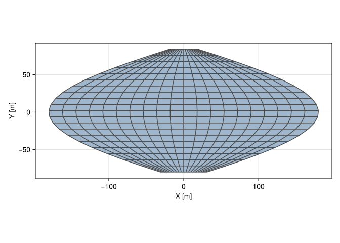

```julia
viz(grid |> Morphological(sinproj), showsegments = true)
```

Examples of `Projected` CRS with a good compromise of shape, area and angle distortion include the `Robinson` and `WinkelTripel`:

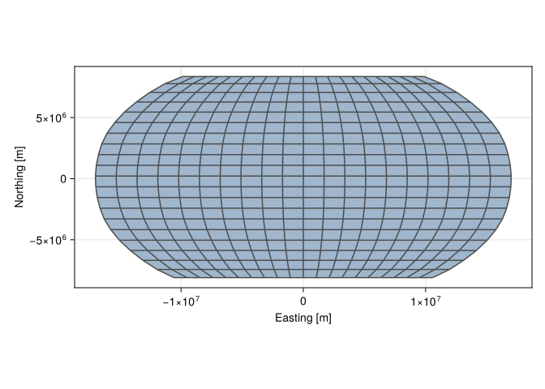

```julia
viz(grid |> Proj(Robinson), showsegments = true)
```

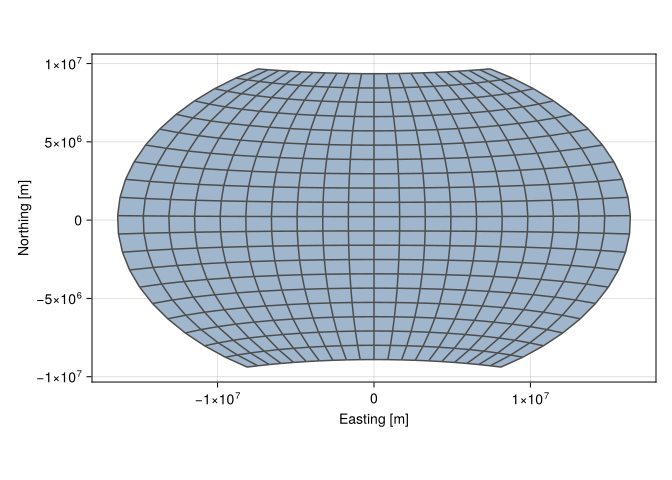

```julia
viz(grid |> Proj(WinkelTripel), showsegments = true)
```

We can create a more realistic map by loading the colors of the Earth stored in a GeoTIFF file:

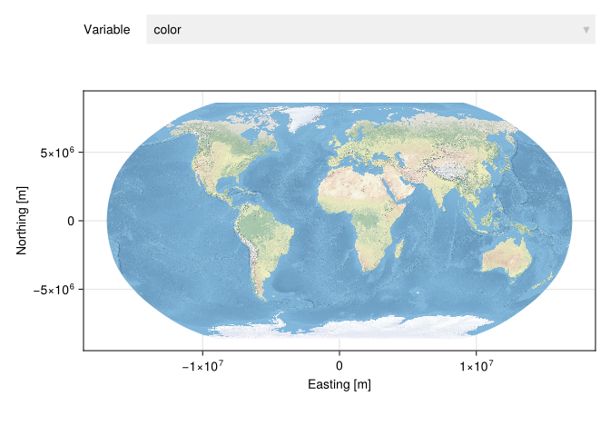

```julia
using GeoIO

earth = GeoIO.load("data/earth.tif")

earth |> Proj(Robinson) |> viewer
```

**NoteTip for all users**

The GeoArtifacts.jl module provides functions to (down)load such data from the web. It includes popular datasets such as [NaturalEarth](https://www.naturalearthdata.com) and [GADM](https://gadm.org). The small `earth.tif` file was generated with the following script:

```julia
using GeoStats
using GeoArtifacts
using GeoIO

geotable = NaturalEarth.naturalearth1("water")

earth = geotable |> Upscale(20, 10)

GeoIO.save("data/earth.tif", earth)
```

Please consult the official documentation for the full list of `Projected` CRS.

## 6.4 UTM

The [Universal Transverse Mercator](https://en.wikipedia.org/wiki/Universal_Transverse_Mercator_coordinate_system) (UTM) system defines a widely used collection of `Projected` CRS as a function of 60 zones in the northern and southern hemispheres. The `utm` function can be used to retrieve the `TransverseMercator` CRS given knowledge of the zone:

```julia
utm(:north, 1)
```

```
TransverseMercator{0.9996, 0.0°, WGS84Latest, CoordRefSystems.Shift{Quantity{Float64, NoDims, Unitful.FreeUnits{(°,), NoDims, nothing}}, Quantity{Float64, 𝐋, Unitful.FreeUnits{(m,), 𝐋, nothing}}}(-177.0°, 500000.0 m, 0.0 m)}
```

```julia
utm(:south, 31)
```

```
TransverseMercator{0.9996, 0.0°, WGS84Latest, CoordRefSystems.Shift{Quantity{Float64, NoDims, Unitful.FreeUnits{(°,), NoDims, nothing}}, Quantity{Float64, 𝐋, Unitful.FreeUnits{(m,), 𝐋, nothing}}}(3.0°, 500000.0 m, 1.0e7 m)}
```

These can be used in the `Proj` transform as usual. The zone number is a function of the longitude and latitude ranges of the domain of interest, and online resources exist to facilitate the identification of this number.

**NoteTip for all users**

The longitude and latitude ranges of a domain can be quickly found with the `boundingbox`:

```julia
boundingbox(grid)
```

```
Box
├─ min: Point(lat: -80.0°, lon: -180.0°)
└─ max: Point(lat: 84.0°, lon: 180.0°)
```

**NoteTip for all users**

The aliases `utmnorth` and `utmsouth` can be used to retrieve UTM zones from a specific hemisphere:

```julia
utmnorth(1) == utm(:north, 1)
```

```
true
```

## 6.5 EPSG/ESRI

The **EPSG Dataset** was created in the mid 80s to catalogue the immense list of CRS in the literature, and their associated projection and datum parameters. It provides a unique identification code for each CRS that can be safely used across geospatial data science projects.

The `CoordRefSystems.get` function can be used to retrieve CRS from `EPSG` or `ESRI` codes:

```julia
CoordRefSystems.get(EPSG{4326})
```

```
GeodeticLatLon{WGS84Latest}
```

```julia
CoordRefSystems.get(EPSG{3395})
```

```
Mercator{WGS84Latest}
```

```julia
CoordRefSystems.get(ESRI{54030})
```

```
Robinson{WGS84Latest}
```

These codes can be used directly in the `Proj` transform:

```julia
Point(LatLon(45, 45)) |> Proj(EPSG{3395})
```

```
Point with Mercator{WGS84Latest} coordinates
├─ x: 5.009377085697311e6 m
└─ y: 5.5912959185533915e6 m
```

This feature is convenient, particularly when the CRS is complex to write.

**NoteTip for all users**

The official [epsg.org](https://epsg.org/search/by-name) website provides tools to search codes in the EPSG Dataset. Other websites such as epsg.io provide alternative tools that are more user-friendly.

We conclude this brief exposition of map projections with a few remarks:

- Getting used to the properties of various CRS takes time, however; this is an important skill to develop as a professional geospatial data scientist.
- Although the literature on map projections requires advanced mathematical background, the `Proj` transform facilitates the experimentation of various CRS in practice.